# Modeling

```python
import numpy as np
import pandas as pd
import matplotlib.pyplot as plt
import seaborn as sns
import statsmodels.api as sm
import statsmodels.formula.api as smf
from sklearn.linear_model import LinearRegression
from sklearn.linear_model import RidgeCV
from sklearn.linear_model import ElasticNetCV
from sklearn.linear_model import LassoCV
from sklearn.cross_validation import train_test_split

%matplotlib inline
```

```python
df = pd.read_csv('MOVIESDF.csv')
```

```python
df.info()
```

```
<class 'pandas.core.frame.DataFrame'>
RangeIndex: 4215 entries, 0 to 4214
Data columns (total 39 columns):
Unnamed: 0           4215 non-null int64
Unnamed: 0.1         4215 non-null int64
Actors               4208 non-null object
Awards               3537 non-null object
BoxOffice            800 non-null object
Country              4213 non-null object
DVD                  4065 non-null object
Director             4168 non-null object
Genre                4212 non-null object
Language             4209 non-null object
Metascore            2782 non-null float64
Plot                 4199 non-null object
Poster               3612 non-null object
Production           4049 non-null object
Rated                4160 non-null object
Released             4206 non-null object
Response             4215 non-null bool
Runtime              4201 non-null object
Title                4215 non-null object
Type                 4215 non-null object
Website              2181 non-null object
Writer               4189 non-null object
Year                 4215 non-null object
imdbID               4215 non-null object
imdbRating           4204 non-null float64
imdbVotes            4204 non-null object
tomatoConsensus      2674 non-null object
tomatoFresh          3944 non-null float64
tomatoImage          3944 non-null object
tomatoMeter          3944 non-null float64
tomatoRating         3944 non-null float64
tomatoReviews        3944 non-null float64
tomatoRotten         3944 non-null float64
tomatoURL            4147 non-null object
tomatoUserMeter      4077 non-null float64
tomatoUserRating     4077 non-null float64
tomatoUserReviews    4147 non-null float64
totalSeasons         34 non-null float64
Gross Adj Profit     4215 non-null object
dtypes: bool(1), float64(11), int64(2), object(25)
memory usage: 1.2+ MB
```

```python
df2 = df[['imdbRating', 'tomatoFresh', 'tomatoMeter', 'tomatoRating','tomatoRotten', 'tomatoUserReviews', 'tomatoUserMeter', 'Gross Adj Profit']]
```

```python
df2 = df2.dropna(how = 'any')
```

```python
df2['Gross_Adj_Profit'] = df2['Gross Adj Profit'].str.replace("$", "").str.replace(",", "").astype(float)
df2 = df2.drop("Gross Adj Profit", axis = 1)
```

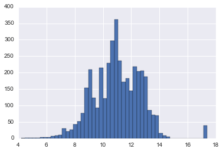

```python
df2.head()
plt.hist(np.log(df2['tomatoUserReviews']), bins = 50)
```

```python
df2.corr()
```

|  | imdbRating | tomatoFresh | tomatoMeter | tomatoRating | tomatoRotten | tomatoUserReviews | tomatoUserMeter | Gross_Adj_Profit |
| --- | --- | --- | --- | --- | --- | --- | --- | --- |
| imdbRating | 1.000000 | 0.525993 | 0.787094 | 0.830265 | -0.301258 | 0.076759 | 0.858043 | 0.290809 |
| tomatoFresh | 0.525993 | 1.000000 | 0.553152 | 0.597786 | 0.100008 | 0.137107 | 0.433923 | 0.198392 |
| tomatoMeter | 0.787094 | 0.553152 | 1.000000 | 0.962787 | -0.497383 | 0.050221 | 0.722065 | 0.270880 |
| tomatoRating | 0.830265 | 0.597786 | 0.962787 | 1.000000 | -0.427292 | 0.059706 | 0.738515 | 0.297298 |
| tomatoRotten | -0.301258 | 0.100008 | -0.497383 | -0.427292 | 1.000000 | 0.058287 | -0.349235 | -0.074280 |
| tomatoUserReviews | 0.076759 | 0.137107 | 0.050221 | 0.059706 | 0.058287 | 1.000000 | 0.025701 | 0.202933 |
| tomatoUserMeter | 0.858043 | 0.433923 | 0.722065 | 0.738515 | -0.349235 | 0.025701 | 1.000000 | 0.273800 |
| Gross_Adj_Profit | 0.290809 | 0.198392 | 0.270880 | 0.297298 | -0.074280 | 0.202933 | 0.273800 | 1.000000 |

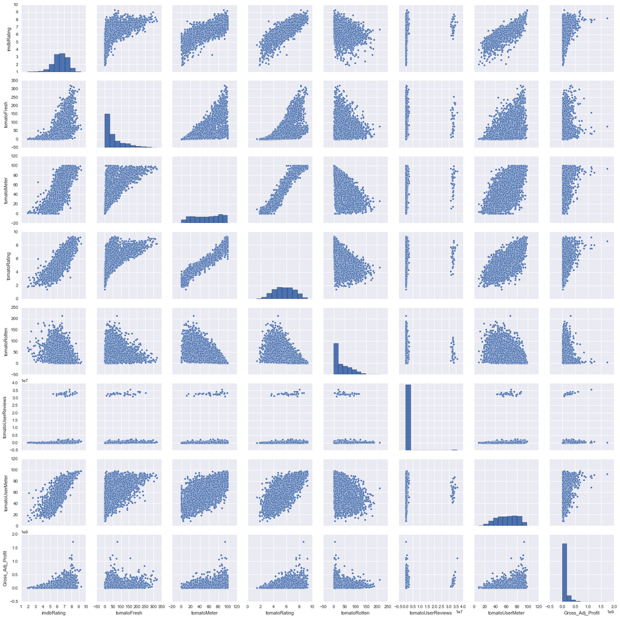

```python
sns.pairplot(df2)
```

# StatsModels

```python
X = df2.drop('Gross_Adj_Profit', axis = 1)
y = df2['Gross_Adj_Profit']
X = sm.add_constant(X)
lmorig = sm.OLS(y, X)
```

```python
fitorig = lmorig.fit()
fitorig.summary()
```

OLS Regression Results

| Dep. Variable: | Gross_Adj_Profit | R-squared: | 0.135 |
| --- | --- | --- | --- |
| Model: | OLS | Adj. R-squared: | 0.133 |
| Method: | Least Squares | F-statistic: | 87.28 |
| Date: | Tue, 04 Oct 2016 | Prob (F-statistic): | 1.68e-118 |
| Time: | 15:43:01 | Log-Likelihood: | -78215. |
| No. Observations: | 3939 | AIC: | 1.564e+05 |
| Df Residuals: | 3931 | BIC: | 1.565e+05 |
| Df Model: | 7 |  |  |
| Covariance Type: | nonrobust |  |  |

|  | coef | std err | t | P>\|t\| | [95.0% Conf. Int.] |
| --- | --- | --- | --- | --- | --- |
| const | -9.166e+07 | 1.7e+07 | -5.403 | 0.000 | -1.25e+08 -5.84e+07 |
| imdbRating | 1.618e+06 | 3.98e+06 | 0.406 | 0.685 | -6.19e+06 9.42e+06 |
| tomatoFresh | -4.984e+04 | 4.06e+04 | -1.228 | 0.219 | -1.29e+05 2.97e+04 |
| tomatoMeter | -6.37e+05 | 2.29e+05 | -2.781 | 0.005 | -1.09e+06 -1.88e+05 |
| tomatoRating | 2.704e+07 | 4.56e+06 | 5.934 | 0.000 | 1.81e+07 3.6e+07 |
| tomatoRotten | 1.3e+05 | 6e+04 | 2.166 | 0.030 | 1.23e+04 2.48e+05 |
| tomatoUserReviews | 6.2361 | 0.505 | 12.339 | 0.000 | 5.245 7.227 |
| tomatoUserMeter | 7.173e+05 | 1.69e+05 | 4.244 | 0.000 | 3.86e+05 1.05e+06 |

| Omnibus: | 3386.807 | Durbin-Watson: | 1.785 |
| --- | --- | --- | --- |
| Prob(Omnibus): | 0.000 | Jarque-Bera (JB): | 163209.382 |
| Skew: | 3.858 | Prob(JB): | 0.00 |
| Kurtosis: | 33.576 | Cond. No. | 3.50e+07 |

# SKLearn

```python
X_train, X_test, y_train, y_test = train_test_split(X, y, test_size = 0.2)
```

```python
modelfit = LinearRegression()
modelfit.fit(X_train, y_train)
modelfit.score(X_test, y_test)
```

```
0.093657453832604487
```

```python
model2 = RidgeCV(alphas = (0.1, 1, 10, 100, 1000), cv = 10)
model2.fit(X_train, y_train)
print model2.score(X_test, y_test)
print model2.alpha_
print model2.coef_
```

```
0.0929772761949
100
[  0.00000000e+00   1.07070881e+06  -7.24511479e+03  -3.89076091e+05
   2.09893282e+07   9.14424663e+04   6.64454610e+00   7.73863195e+05]
```

# Model1 - Add Log

```python
df2['log_tomUserRev'] = df2['tomatoUserReviews'].map(lambda x: np.log(x))
```

```python
X = df2.drop(['Gross_Adj_Profit', 'tomatoUserReviews'], axis = 1)
X_train, X_test, y_train, y_test = train_test_split(X, y, test_size = 0.2)
```

```python
model1 = RidgeCV(alphas = (0.1, 1, 10, 100, 1000), cv = 10)
model1.fit(X_train, y_train)
print model1.score(X_test, y_test)
```

```
0.239463568843
```

# Model2 - ElasticNet

```python
df2.head()
```

|  | imdbRating | tomatoFresh | tomatoMeter | tomatoRating | tomatoRotten | tomatoUserReviews | tomatoUserMeter | Gross_Adj_Profit | log_tomUserRev |
| --- | --- | --- | --- | --- | --- | --- | --- | --- | --- |
| 0 | 6.0 | 15.0 | 71.0 | 6.4 | 6.0 | 14613.0 | 54.0 | 258300900.0 | 9.589667 |
| 1 | 4.9 | 21.0 | 11.0 | 3.9 | 170.0 | 121303.0 | 36.0 | 62544300.0 | 11.706047 |
| 2 | 7.3 | 89.0 | 68.0 | 6.2 | 41.0 | 32088.0 | 81.0 | 58070300.0 | 10.376237 |
| 3 | 7.2 | 44.0 | 98.0 | 8.1 | 1.0 | 708348.0 | 75.0 | 487118900.0 | 13.470691 |
| 4 | 4.8 | 28.0 | 31.0 | 4.4 | 62.0 | 406385.0 | 32.0 | 106651500.0 | 12.915056 |

```python
model2 = ElasticNetCV(cv = 10)
model2.fit(X_train, y_train)
print model2.score(X_test, y_test)
```

```
-0.00292045075942
```

# Model3 - Lasso

```python
model3 = LassoCV(cv = 10)
model3.fit(X_train, y_train)
print model3.score(X_test, y_test)
```

```
0.235923175141
```

```
103461131.1
```

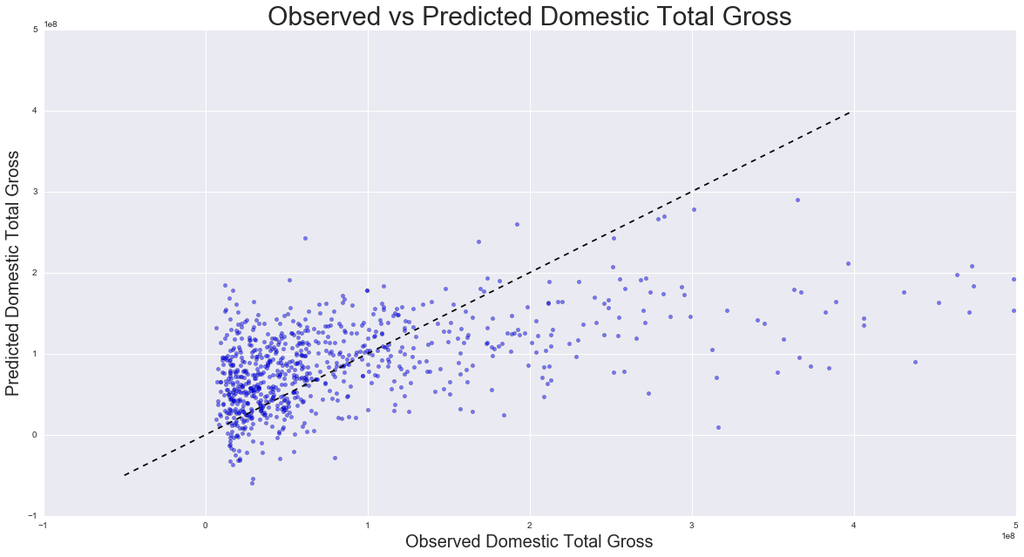

```python
y_predict = model3.predict(X_test)
RMSE_lr = np.sqrt(np.sum((y_predict - y_test)**2)/len(y_test))
print RMSE_lr

plt.figure(figsize = (20,10))
plt.xlim(-100000000, 500000000)
line = np.linspace(-50000000, 400000000, 200)
plt.scatter(y_test, y_predict, alpha = 0.5)
plt.xlabel("Observed Domestic Total Gross", fontsize = 20)
plt.ylabel("Predicted Domestic Total Gross", fontsize = 20)
plt.title("Observed vs Predicted Domestic Total Gross", fontsize = 30)
plt.plot(line, line, 'k--')
```

Theaters must pays fees to the movie studios for choosing to show their movies. In doing so, they must decide which movies are the best ones to show to maximize their returns. Many times, it is difficult to choose which movies to show; therefore, it would be extremely advantageous to be able to predict the amount of revenue a certain movie would bring in early on. The ratings of a movie, from sources such as IMDB and Rotten Tomatoes, could be great predictors. Therefore, domestic total gross (inflated to 2016) was scraped from the top 4000 movies of all time, along with their ratings, in order to measure this phenomenon. The original R squared value, using a linear regression, returned a value of 0.13. Testing the data using the log of one of the features, the number of Rotten Tomatoes reviews, generated a higher R squared of 0.24. Testing it with the Lasso and Elastic Net did not significantly improve the R squared value.